# Ordinal Regression Coefficient Interpretation

Cumulative Logit Models and Proportional Odds

## 1. What is Ordinal Regression?

Ordinal regression is used when the outcome variable has **ordered categories** that have a natural ranking but the distances between categories are not necessarily equal.

### Examples of Ordinal Outcomes

| Domain | Categories |
| --- | --- |
| **Pain severity** | None < Mild < Moderate < Severe |
| **Disease stage** | Stage I < Stage II < Stage III < Stage IV |
| **Agreement scale** | Strongly Disagree < Disagree < Neutral < Agree < Strongly Agree |
| **Functional status** | Independent < Some assistance < Dependent |
| **Treatment response** | No response < Partial response < Complete response |

### The Cumulative Logit Model

The most common ordinal regression model is the **cumulative logit model** (also called proportional odds model). It models the probability of being at or below each category.

**Link function:**
$$\text{logit}(P(Y \leq j)) = \log\left(\frac{P(Y \leq j)}{P(Y > j)}\right)$$

This is the log-odds of being in category $j$ or lower versus being in a higher category.

### Key Feature: Single Coefficient

The proportional odds model uses a **single coefficient** for each predictor across all cut points. This assumes the effect of the predictor is the same regardless of where you “cut” the outcome scale.

**ImportantWhy Ordinal, Not Multinomial?**

Ordinal regression **uses the ordering information** in your outcome. Multinomial regression ignores this ordering, treating categories as unrelated. Ordinal regression is more efficient and interpretable when the outcome is truly ordered.

## 2. The Model

### Mathematical Formulation

For an outcome $Y$ with $J$ ordered categories (1, 2, …, J), the cumulative logit model is:

$$\text{logit}(P(Y \leq j | \mathbf{X})) = \alpha_j - \boldsymbol{\beta}^T\mathbf{X}$$

for $j = 1, 2, \ldots, J-1$

where:

| Component | Description |
| --- | --- |
| $\alpha_j$ | Threshold (intercept) for cumulative probability up to category $j$ |
| $\boldsymbol{\beta}$ | Vector of regression coefficients |
| $\mathbf{X}$ | Vector of covariates |

### Understanding the Thresholds

There are $J-1$ thresholds for $J$ categories:

- $\alpha_1$: threshold between category 1 and categories 2-J
- $\alpha_2$: threshold between categories 1-2 and categories 3-J
- $\vdots$
- $\alpha_{J-1}$: threshold between categories 1 to J-1 and category J

The thresholds are **ordered**: $\alpha_1 < \alpha_2 < \cdots < \alpha_{J-1}$

**WarningThe Sign Convention Varies by Software!**

Some software (including `polr` and `clm`) uses the model:
$$\text{logit}(P(Y \leq j | \mathbf{X})) = \alpha_j - \boldsymbol{\beta}^T\mathbf{X}$$

Other software uses:
$$\text{logit}(P(Y \leq j | \mathbf{X})) = \alpha_j + \boldsymbol{\beta}^T\mathbf{X}$$

**This changes the interpretation of positive/negative coefficients!** See Section 5 for details.

### Implied Category Probabilities

From the cumulative model, we can derive individual category probabilities:

$$P(Y = j | \mathbf{X}) = P(Y \leq j | \mathbf{X}) - P(Y \leq j-1 | \mathbf{X})$$

where $P(Y \leq 0) = 0$ and $P(Y \leq J) = 1$ by convention.

## 3. Coefficient Interpretation

### The Proportional Odds Interpretation

For `MASS::polr` and `ordinal::clm` (which use the **minus sign** convention):

| Coefficient Sign | Interpretation |
| --- | --- |
| $\beta > 0$ | Higher values of $X$ associated with **higher** outcome categories |
| $\beta < 0$ | Higher values of $X$ associated with **lower** outcome categories |
| $\exp(\beta)$ | **Cumulative odds ratio** for higher vs. lower categories |

### What is the Cumulative Odds Ratio?

The cumulative odds ratio $\exp(\beta)$ compares:

$$\text{OR} = \frac{\text{Odds}(Y > j | X = x+1)}{\text{Odds}(Y > j | X = x)} = \exp(\beta)$$

This is the same at **every cut point** (the proportional odds assumption).

### Interpretation Template

For a one-unit increase in $X$:

> “A one-unit increase in $X$ is associated with $\exp(\beta)$ times the odds of being in a **higher** category versus a **lower** category (or any categories above threshold $j$ versus at or below $j$).”

### Example Interpretations

| Scenario | $\beta$ | $\exp(\beta)$ | Interpretation |
| --- | --- | --- | --- |
| Treatment effect | 0.85 | 2.34 | Treatment associated with 2.34 times odds of higher category |
| Age effect | -0.03 | 0.97 | Each year of age associated with 3% lower odds of higher category |
| Dose effect | 1.20 | 3.32 | Each unit increase in dose associated with 3.32 times odds of higher category |

**NoteHigher vs. Lower Categories**

The cumulative odds ratio applies to the odds of being **above** any cutpoint versus **at or below** it. Because of the proportional odds assumption, this ratio is constant across all cutpoints.

## 4. The Proportional Odds Assumption

### What It Means

The proportional odds assumption states that the effect of each predictor is **constant** across all cutpoints of the outcome. Mathematically:

$$\frac{\text{Odds}(Y > j | X = x+1)}{\text{Odds}(Y > j | X = x)} = \exp(\beta) \text{ for all } j$$

### Visual Representation

[figure not shown]

### When Proportional Odds Fails

The assumption may be violated when:

- Different predictors have different effects at different severity levels
- There are “ceiling” or “floor” effects
- The categories are not truly ordinal
- Sample size is small at extreme categories

### Testing: The Brant Test

```r
# Using the brant package
library(brant)
brant(polr_model)

# Interpretation:
# - Non-significant p-values suggest proportional odds is reasonable
# - Significant p-values indicate violation for that predictor
```

### Alternatives When Assumption Fails

| Alternative | Description |
| --- | --- |
| **Partial proportional odds** | Allow some predictors to have different effects at each cutpoint |
| **Multinomial logit** | Abandon ordering, treat as nominal |
| **Adjacent-category logit** | Model odds of adjacent categories |
| **Continuation-ratio logit** | Model sequential transitions |
| **Stereotype model** | Ordinal model without proportional odds |

The `ordinal::clm` package allows partial proportional odds models via the `nominal` argument.

## 5. Software Sign Conventions

**ImportantCritical: Know Your Software’s Convention!**

Different software packages use different sign conventions. Getting this wrong leads to completely reversed interpretations!

### Sign Convention Comparison

| Package | Model Form | Positive $\beta$ Means | Notes |
| --- | --- | --- | --- |
| `MASS::polr` (R) | $\text{logit}(P(Y \leq j)) = \alpha_j - \beta X$ | Higher $X$ $\to$ **higher** $Y$ | Most common in R |
| `ordinal::clm` (R) | $\text{logit}(P(Y \leq j)) = \alpha_j - \beta X$ | Higher $X$ $\to$ **higher** $Y$ | Same as `polr` |
| `VGAM::vglm` (R) | $\text{logit}(P(Y \leq j)) = \alpha_j - \beta X$ | Higher $X$ $\to$ **higher** $Y$ | Uses “propodds” family |
| SAS PROC LOGISTIC | Depends on `DESCENDING` option | Check output! | Default may vary |
| Stata `ologit` | $\text{logit}(P(Y \leq j)) = \alpha_j - \beta X$ | Higher $X$ $\to$ **higher** $Y$ | Same convention |

### How to Verify Your Software’s Convention

**Always verify with predicted probabilities:**

```r
# Create simple test data
set.seed(667)
test_dat <- data.frame(
  y = factor(c(rep(1, 20), rep(2, 30), rep(3, 30), rep(4, 20)),
             ordered = TRUE, levels = 1:4),
  x = c(rnorm(20, 0), rnorm(30, 1), rnorm(30, 2), rnorm(20, 3))
)

# Fit model
test_fit <- polr(y ~ x, data = test_dat)

# Get predictions for low and high x
pred_low <- predict(test_fit, newdata = data.frame(x = 0), type = "probs")
pred_high <- predict(test_fit, newdata = data.frame(x = 3), type = "probs")

cat("Predicted probabilities for x = 0:\n")
```

```
Predicted probabilities for x = 0:
```

```r
print(round(pred_low, 3))
```

```
    1     2     3     4
0.466 0.422 0.096 0.016
```

```r
cat("\nPredicted probabilities for x = 3:\n")
```

```
Predicted probabilities for x = 3:
```

```r
print(round(pred_high, 3))
```

```
    1     2     3     4
0.024 0.161 0.455 0.359
```

```r
# Check: If beta > 0 in polr, higher x should have more probability in higher categories
cat("\nCoefficient for x:", coef(test_fit), "\n")
```

```
Coefficient for x: 1.185755
```

```r
cat("Beta > 0, so higher x should give more probability in higher categories\n")
```

```
Beta > 0, so higher x should give more probability in higher categories
```

```r
cat("Sum of P(Y=3) + P(Y=4) for x=0:", sum(pred_low[3:4]), "\n")
```

```
Sum of P(Y=3) + P(Y=4) for x=0: 0.1112349
```

```r
cat("Sum of P(Y=3) + P(Y=4) for x=3:", sum(pred_high[3:4]), "\n")
```

```
Sum of P(Y=3) + P(Y=4) for x=3: 0.814433
```

## 6. Worked Example

### Pain Severity Data

Let’s analyze a simulated clinical trial examining the effect of treatment on pain severity.

```r
set.seed(667)

# Simulate pain severity data
n <- 200

# Covariates
treatment <- factor(rep(c("Placebo", "Treatment"), each = n/2))
age <- round(rnorm(n, mean = 50, sd = 12))
baseline_pain <- sample(1:4, n, replace = TRUE, prob = c(0.1, 0.3, 0.4, 0.2))

# Generate ordinal outcome (1=none, 2=mild, 3=moderate, 4=severe)
# Treatment reduces pain (negative effect on severity)
# Higher baseline pain associated with higher post-treatment pain
eta <- -0.8 * (treatment == "Treatment") + 0.4 * (baseline_pain - 2) + 0.02 * (age - 50)

# Convert to ordinal using latent variable approach
latent <- eta + rlogis(n)
thresholds <- c(-2, 0, 2)
pain <- cut(latent, breaks = c(-Inf, thresholds, Inf), labels = c("None", "Mild", "Moderate", "Severe"))
pain <- ordered(pain, levels = c("None", "Mild", "Moderate", "Severe"))

# Create data frame
pain_data <- data.frame(
  pain = pain,
  treatment = treatment,
  age = age,
  baseline_pain = factor(baseline_pain, labels = c("None", "Mild", "Moderate", "Severe"))
)

# View data summary
table(pain_data$pain, pain_data$treatment)
```

```
           Placebo Treatment
  None           6        18
  Mild          32        43
  Moderate      44        30
  Severe        18         9
```

### Fit the Proportional Odds Model

```r
# Fit with MASS::polr
fit_polr <- polr(pain ~ treatment + age + baseline_pain, data = pain_data, Hess = TRUE)

# Summary
summary(fit_polr)
```

```
Call:
polr(formula = pain ~ treatment + age + baseline_pain, data = pain_data,
    Hess = TRUE)

Coefficients:
                         Value Std. Error  t value
treatmentTreatment    -0.91121    0.27172 -3.35347
age                    0.02162    0.01083  1.99631
baseline_painMild      0.02020    0.49586  0.04073
baseline_painModerate  0.13001    0.47686  0.27264
baseline_painSevere    0.59996    0.51378  1.16774

Intercepts:
                Value   Std. Error t value
None|Mild       -1.2982  0.7122    -1.8228
Mild|Moderate    0.8153  0.7039     1.1583
Moderate|Severe  2.8133  0.7289     3.8595

Residual Deviance: 483.5691
AIC: 499.5691
```

### Extract and Interpret Coefficients

```r
# Extract coefficients and standard errors
coef_table <- coef(summary(fit_polr))
print(coef_table)
```

```
                            Value Std. Error     t value
treatmentTreatment    -0.91121273  0.2717222 -3.35347217
age                    0.02161582  0.0108279  1.99630890
baseline_painMild      0.02019649  0.4958551  0.04073064
baseline_painModerate  0.13001071  0.4768640  0.27263685
baseline_painSevere    0.59996023  0.5137806  1.16773628
None|Mild             -1.29821845  0.7122048 -1.82281628
Mild|Moderate          0.81531325  0.7038868  1.15830159
Moderate|Severe        2.81326072  0.7289095  3.85954711
```

```r
# Calculate odds ratios and 95% CIs
beta <- coef_table[, "Value"]
se <- coef_table[, "Std. Error"]

# Create results table
results <- data.frame(
  Variable = names(beta),
  Coefficient = beta,
  SE = se,
  OR = exp(beta),
  OR_Lower = exp(beta - 1.96 * se),
  OR_Upper = exp(beta + 1.96 * se),
  z_value = beta / se,
  p_value = 2 * (1 - pnorm(abs(beta / se)))
)

print(results, digits = 3)
```

```
                                   Variable Coefficient     SE     OR OR_Lower
treatmentTreatment       treatmentTreatment     -0.9112 0.2717  0.402   0.2360
age                                     age      0.0216 0.0108  1.022   1.0004
baseline_painMild         baseline_painMild      0.0202 0.4959  1.020   0.3861
baseline_painModerate baseline_painModerate      0.1300 0.4769  1.139   0.4472
baseline_painSevere     baseline_painSevere      0.6000 0.5138  1.822   0.6656
None|Mild                         None|Mild     -1.2982 0.7122  0.273   0.0676
Mild|Moderate                 Mild|Moderate      0.8153 0.7039  2.260   0.5688
Moderate|Severe             Moderate|Severe      2.8133 0.7289 16.664   3.9932
                      OR_Upper z_value  p_value
treatmentTreatment       0.685 -3.3535 0.000798
age                      1.044  1.9963 0.045900
baseline_painMild        2.697  0.0407 0.967511
baseline_painModerate    2.900  0.2726 0.785132
baseline_painSevere      4.988  1.1677 0.242913
None|Mild                1.103 -1.8228 0.068331
Mild|Moderate            8.979  1.1583 0.246741
Moderate|Severe         69.541  3.8595 0.000114
```

### Interpretation

**Treatment effect:**

- Coefficient = -0.911
- Odds Ratio = 0.402

Since we are using `polr` (minus sign convention) and $\beta < 0$:

> “Patients receiving treatment have 0.4 times the odds of being in a **higher** (more severe) pain category compared to placebo. Equivalently, treatment is associated with 2.49 times the odds of being in a **lower** (less severe) pain category.”

Or more intuitively:

> “Treatment reduces the odds of higher pain severity by 60% compared to placebo.”

## 7. Predicted Probabilities

### Calculating Category Probabilities

```r
# Get predicted probabilities for all observations
pred_probs <- predict(fit_polr, type = "probs")
head(pred_probs)
```

```
        None      Mild  Moderate    Severe
1 0.10128315 0.3813448 0.3904477 0.1269243
2 0.06276345 0.2938643 0.4468094 0.1965629
3 0.03261985 0.1855883 0.4547970 0.3269948
4 0.04101662 0.2204490 0.4615726 0.2769618
5 0.09367970 0.3674043 0.4020973 0.1368187
6 0.07841689 0.3348390 0.4252869 0.1614572
```

### Predictions for Specific Covariate Values

```r
# Create prediction scenarios
new_data <- expand.grid(
  treatment = c("Placebo", "Treatment"),
  age = 50,
  baseline_pain = "Moderate"
)

# Get predicted probabilities
pred_scenarios <- predict(fit_polr, newdata = new_data, type = "probs")
pred_scenarios <- as.data.frame(pred_scenarios)
pred_scenarios <- cbind(new_data[, "treatment", drop = FALSE], pred_scenarios)

print(pred_scenarios, digits = 3)
```

```
  treatment   None  Mild Moderate Severe
1   Placebo 0.0752 0.327    0.430 0.1676
2 Treatment 0.1683 0.458    0.299 0.0749
```

### Visualization of Predicted Probabilities

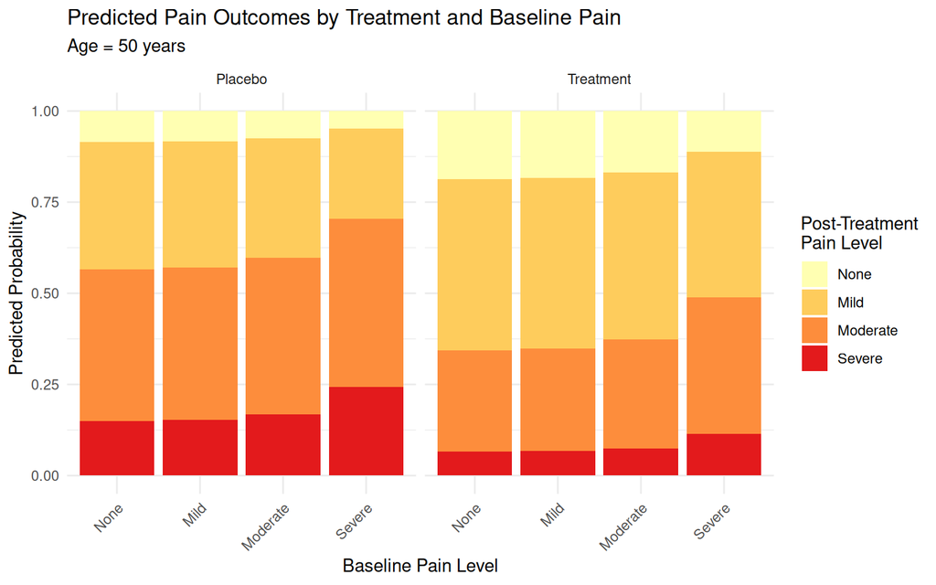

```r
# Create data for plotting
plot_data <- expand.grid(
  treatment = c("Placebo", "Treatment"),
  age = 50,
  baseline_pain = c("None", "Mild", "Moderate", "Severe")
)

pred_plot <- predict(fit_polr, newdata = plot_data, type = "probs")
plot_data <- cbind(plot_data, pred_plot)

# Reshape for plotting
library(tidyr)
plot_long <- pivot_longer(plot_data, cols = c("None", "Mild", "Moderate", "Severe"),
                          names_to = "Pain_Level", values_to = "Probability")
plot_long$Pain_Level <- factor(plot_long$Pain_Level,
                                levels = c("None", "Mild", "Moderate", "Severe"))

ggplot(plot_long, aes(x = baseline_pain, y = Probability, fill = Pain_Level)) +
  geom_bar(stat = "identity", position = "stack") +
  facet_wrap(~ treatment) +
  scale_fill_brewer(palette = "YlOrRd", name = "Post-Treatment\nPain Level") +
  labs(x = "Baseline Pain Level", y = "Predicted Probability",
       title = "Predicted Pain Outcomes by Treatment and Baseline Pain",
       subtitle = "Age = 50 years") +
  theme_minimal() +
  theme(axis.text.x = element_text(angle = 45, hjust = 1))
```

### Cumulative Probability Curves

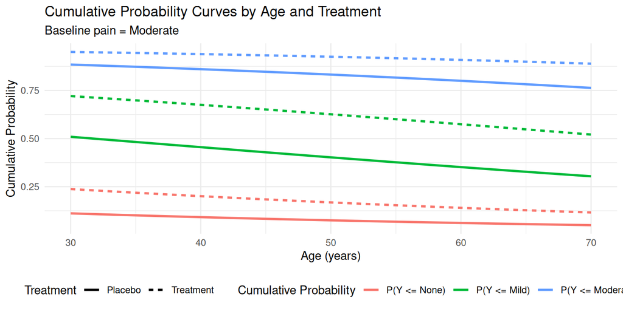

```r
# Calculate cumulative probabilities across age range
age_range <- data.frame(
  treatment = rep(c("Placebo", "Treatment"), each = 50),
  age = rep(seq(30, 70, length.out = 50), 2),
  baseline_pain = "Moderate"
)

# Get cumulative probabilities
pred_age <- predict(fit_polr, newdata = age_range, type = "probs")
age_range <- cbind(age_range, pred_age)

# Calculate cumulative probabilities
age_range$cum_mild <- age_range$None + age_range$Mild
age_range$cum_moderate <- age_range$cum_mild + age_range$Moderate

# Plot
plot_cum <- pivot_longer(age_range,
                         cols = c("None", "cum_mild", "cum_moderate"),
                         names_to = "Cumulative", values_to = "Prob")
plot_cum$Cumulative <- factor(plot_cum$Cumulative,
                              levels = c("None", "cum_mild", "cum_moderate"),
                              labels = c("P(Y <= None)", "P(Y <= Mild)", "P(Y <= Moderate)"))

ggplot(plot_cum, aes(x = age, y = Prob, color = Cumulative, linetype = treatment)) +
  geom_line(linewidth = 1) +
  labs(x = "Age (years)", y = "Cumulative Probability",
       title = "Cumulative Probability Curves by Age and Treatment",
       subtitle = "Baseline pain = Moderate",
       color = "Cumulative Probability",
       linetype = "Treatment") +
  theme_minimal() +
  theme(legend.position = "bottom")
```

## 8. Using emmeans for Adjusted Probabilities

The `emmeans` package provides an elegant way to obtain adjusted predicted probabilities and contrasts.

### Adjusted Probabilities by Treatment

```r
# Get adjusted predicted probabilities
em_probs <- emmeans(fit_polr, ~ pain | treatment, mode = "prob")
summary(em_probs)
```

```
treatment = Placebo:
 pain       prob     SE  df asymp.LCL asymp.UCL
 None     0.0721 0.0194 Inf    0.0342     0.110
 Mild     0.3156 0.0401 Inf    0.2371     0.394
 Moderate 0.4320 0.0412 Inf    0.3512     0.513
 Severe   0.1803 0.0356 Inf    0.1104     0.250

treatment = Treatment:
 pain       prob     SE  df asymp.LCL asymp.UCL
 None     0.1615 0.0350 Inf    0.0928     0.230
 Mild     0.4471 0.0421 Inf    0.3646     0.530
 Moderate 0.3096 0.0401 Inf    0.2310     0.388
 Severe   0.0817 0.0207 Inf    0.0412     0.122

Results are averaged over the levels of: baseline_pain
Confidence level used: 0.95
```

```r
# Treatment comparison on odds ratio scale
em_or <- emmeans(fit_polr, ~ treatment, mode = "latent")
pairs(em_or, type = "response")
```

```
 contrast            estimate    SE  df z.ratio p.value
 Placebo - Treatment    0.911 0.272 Inf   3.353  0.0008

Results are averaged over the levels of: baseline_pain
```

### Marginal Effects

```r
# Joint reference grid
em_joint <- emmeans(fit_polr, ~ treatment, mode = "latent")
summary(em_joint)
```

```
 treatment emmean    SE  df asymp.LCL asymp.UCL
 Placebo    0.503 0.205 Inf     0.100  0.905589
 Treatment -0.408 0.209 Inf    -0.817  0.000719

Results are averaged over the levels of: baseline_pain
Confidence level used: 0.95
```

```r
# Contrast (log-odds scale)
contrast(em_joint, method = "pairwise")
```

```
 contrast            estimate    SE  df z.ratio p.value
 Placebo - Treatment    0.911 0.272 Inf   3.353  0.0008

Results are averaged over the levels of: baseline_pain
```

### Plotting emmeans Results

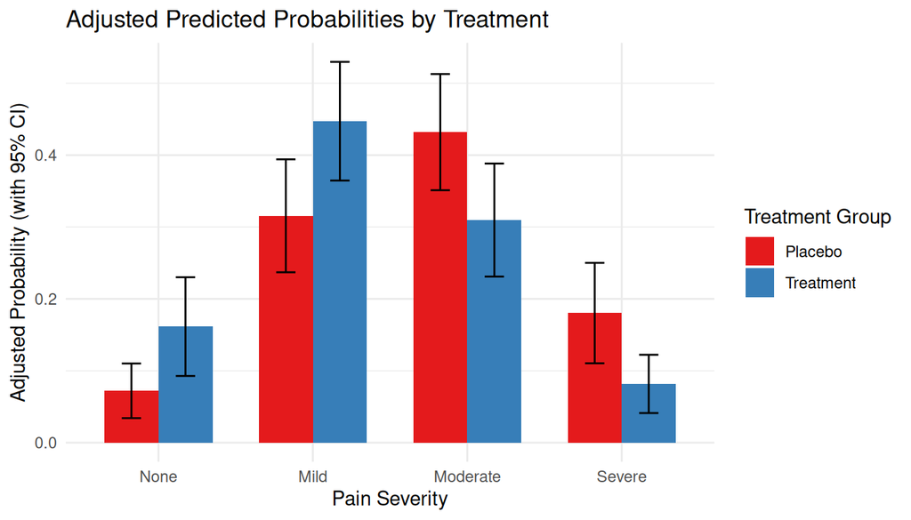

```r
# Extract probability estimates for plotting
em_summary <- as.data.frame(summary(em_probs))

ggplot(em_summary, aes(x = pain, y = prob, fill = treatment)) +
  geom_bar(stat = "identity", position = "dodge", width = 0.7) +
  geom_errorbar(aes(ymin = asymp.LCL, ymax = asymp.UCL),
                position = position_dodge(0.7), width = 0.25) +
  labs(x = "Pain Severity", y = "Adjusted Probability (with 95% CI)",
       title = "Adjusted Predicted Probabilities by Treatment",
       fill = "Treatment Group") +
  scale_fill_brewer(palette = "Set1") +
  theme_minimal()
```

## 9. Common Mistakes

### Mistake 1: Getting the Sign Wrong

```r
# WRONG: Interpreting positive coefficient as lower outcome
# "Treatment (beta = 0.8) is associated with lower pain"

# CORRECT for polr/clm: Positive coefficient means HIGHER category
# "Treatment (beta = 0.8) is associated with HIGHER pain severity"
```

**Always verify with predicted probabilities!**

### Mistake 2: Interpreting as Probability

```r
# WRONG
# "A one-unit increase in X increases the probability of higher category by exp(beta)"

# CORRECT
# "A one-unit increase in X multiplies the ODDS of higher category by exp(beta)"
```

### Mistake 3: Ignoring Proportional Odds Violation

```r
# WRONG: Blindly reporting results without checking
summary(fit_polr)

# CORRECT: Test the assumption
library(brant)
brant(fit_polr)  # Check for violations

# If violated, consider alternatives:
# - Partial proportional odds (clm with nominal terms)
# - Multinomial regression
# - Report with caveat about violation
```

### Mistake 4: Forgetting Software Conventions

```r
# Different packages may give different signs!
# Always document which package and verify interpretation

# Example: Compare polr and clm (should be same)
fit_clm <- clm(pain ~ treatment + age + baseline_pain, data = pain_data)

cat("polr coefficient for treatment:", coef(fit_polr)["treatmentTreatment"], "\n")
```

```
polr coefficient for treatment: -0.9112127
```

```r
cat("clm coefficient for treatment:", coef(fit_clm)["treatmentTreatment"], "\n")
```

```
clm coefficient for treatment: -0.9112215
```

### Mistake 5: Treating Ordinal as Continuous

```r
# WRONG: Linear regression on ordinal outcome
lm(as.numeric(pain) ~ treatment, data = pain_data)

# This assumes equal intervals between categories!

# CORRECT: Use ordinal regression
polr(pain ~ treatment, data = pain_data)
```

### Summary of Common Mistakes

| Mistake | Problem | Solution |
| --- | --- | --- |
| Sign reversal | Wrong interpretation direction | Verify with predicted probabilities |
| Probability vs odds | Misinterpret coefficient magnitude | Report as odds ratio |
| Ignoring proportional odds | Invalid inference | Test with Brant test |
| Wrong software convention | Completely wrong interpretation | Check package documentation |
| Treating as continuous | Assumes equal intervals | Use proper ordinal model |

## 10. Quick Reference Card

### Interpretation Template

For `MASS::polr` and `ordinal::clm`:

**TipStandard Interpretation**

“A one-unit increase in $X$ is associated with $\exp(\beta)$ = **[value]** times the odds of being in a **higher** versus **lower** category of $Y$.”

Or equivalently:

“A one-unit increase in $X$ is associated with $\exp(\beta)$ times the odds of being **above** any given threshold versus **at or below** that threshold.”

### Quick Formulas

| Quantity | Formula |
| --- | --- |
| Odds ratio | $\text{OR} = \exp(\beta)$ |
| 95% CI for OR | $\exp(\beta \pm 1.96 \times \text{SE})$ |
| Probability $P(Y \leq j)$ | $\text{logit}^{-1}(\alpha_j - \beta X)$ |
| Probability $P(Y = j)$ | $P(Y \leq j) - P(Y \leq j-1)$ |

### Essential R Code

```r
# Fit model
library(MASS)
fit <- polr(outcome ~ predictor, data = dat, Hess = TRUE)

# Summary with p-values
coef_table <- coef(summary(fit))
p_values <- 2 * (1 - pnorm(abs(coef_table[, "t value"])))

# Odds ratios with CIs
exp(coef(fit))                              # OR
exp(confint(fit))                           # 95% CI for OR

# Predicted probabilities
predict(fit, type = "probs")                # Category probs
predict(fit, type = "class")                # Predicted class

# Test proportional odds
library(brant)
brant(fit)

# Adjusted predictions with emmeans
library(emmeans)
emmeans(fit, ~ predictor, mode = "prob")
```

### Decision Guide

```
Is outcome ordered?
  --> No  --> Use multinomial logistic regression
  --> Yes --> Continue

Are intervals between categories equal?
  --> Yes --> Can consider linear regression (with caution)
  --> No  --> Use ordinal regression

Does proportional odds hold?
  --> Yes --> Standard cumulative logit model (polr, clm)
  --> No  --> Partial proportional odds, multinomial, or alternative models
```

### Package Quick Reference

```r
# Core ordinal regression
library(MASS)        # polr() - standard cumulative logit
library(ordinal)     # clm() - more flexible, allows partial proportional odds

# Diagnostics
library(brant)       # brant() - test proportional odds assumption

# Marginal means and contrasts
library(emmeans)     # emmeans() - adjusted predictions and comparisons

# Visualization
library(ggplot2)     # Plotting
library(effects)     # effect() - effect plots for ordinal models
```

**TipFinal Tips**

1. **Always verify sign convention** with predicted probabilities before interpreting
2. **Test proportional odds assumption** before trusting a single coefficient
3. **Report odds ratios** with confidence intervals, not just coefficients
4. **Visualize predicted probabilities** to communicate results effectively
5. **Use emmeans** for clean marginal predictions and treatment comparisons